# Project 2: Data Mining, Classification, Prediction

SDS322E

# Mining, Classification, Prediction

## Sydney McDaniel, sbm2374

### Introduction

The data set being used for this project is “Presidents”; this set was retrieved from Kaggle.com. Taking a glimpse at this data set, the variables include: Election Year, Candidate Name, Home State, Candidate Party, Popular Vote (number of votes received), Popular Vote Share (as a proportion of the total votes cast in that election), Electoral Vote (number of votes received), and Electoral Vote Share (as a proportion of the total votes cast by electoral college). There were 358 observations in the original data set. However, information regarding popular and electoral votes were missing for some of the candidates. The cleaned data set [i.e., not including these rows] has 319 observations.

The binary variable,-Incumbent [whether the candidate was already President]-, has 287 observations for “N” [No], and 32 observations for “Y” [Yes]. The categorical variable Candidate Party has 62 distinct observations; the categorical variable Home State has 45 distinct observations

As someone who has always been interested in politics/government, I’ll enjoy exploring this data set. There are lots of qualitative variables that can be compared to the categorical variable, Candidate Party, [Independent, Federalist, Democratic, etc] and the binary variable, Incumbent. Before performing any analyses, I predict that incumbent candidates will have higher electoral and popular vote shares than those who were not incumbents.

##### Importing data

```r
library(tidyverse)
library(readr)
US_Presidential_Election_Results_ResultsByCandidate <- read_csv("~/project2/US Presidential Election Results - ResultsByCandidate.csv",
    col_types = cols(ElectionYear = col_number(), PopularVote = col_number(),
        PopVoteShare = col_number(), ElectoralVotes = col_number(),
        ElecVoteShare = col_number()))
```

##### Cleaning up data

```r
Presidents <- US_Presidential_Election_Results_ResultsByCandidate %>%
    filter(!PopularVote == 0) %>% select(-CandPartyAbbrev)
Presidents$Incumbent <- Presidents$`Incumbent?`
glimpse(Presidents)
```

```
## Rows: 319
## Columns: 10
## $ ElectionYear   <dbl> 1788, 1792, 1796, 1796, 1800, 1800, 1804, 1804, 1808, 1…
## $ CandidateName  <chr> "George Washington", "George Washington", "John Adams",…
## $ HomeState      <chr> "Virginia", "Virginia", "Massachusetts", "Virginia", "V…
## $ `Incumbent?`   <chr> "N", "Y", "N", "N", "N", "Y", "Y", "N", "N", "N", "N", …
## $ CandParty      <chr> "Independent", "Independent", "Federalist", "Democratic…
## $ PopularVote    <dbl> 39624, 28300, 35726, 31115, 45467, 29621, 104110, 38919…
## $ PopVoteShare   <dbl> 100.00, 100.00, 53.45, 46.55, 60.51, 39.42, 72.79, 27.2…
## $ ElectoralVotes <dbl> 69, 132, 71, 68, 73, 65, 162, 14, 122, 47, 0, 128, 89, …
## $ ElecVoteShare  <dbl> 100.00, 100.00, 51.45, 49.28, 52.90, 47.10, 92.05, 7.95…
## $ Incumbent      <chr> "N", "Y", "N", "N", "N", "Y", "Y", "N", "N", "N", "N", …
```

##### How Many Observations for Binary Variable?

```r
Presidents %>% filter(Incumbent == "N")
```

```
## # A tibble: 287 x 10
##    ElectionYear CandidateName       HomeState `Incumbent?` CandParty PopularVote
##           <dbl> <chr>               <chr>     <chr>        <chr>           <dbl>
##  1         1788 George Washington   Virginia  N            Independ…       39624
##  2         1796 John Adams          Massachu… N            Federali…       35726
##  3         1796 Thomas Jefferson    Virginia  N            Democrat…       31115
##  4         1800 Thomas Jefferson    Virginia  N            Democrat…       45467
##  5         1804 Charles C. Pinckney South Ca… N            Federali…       38919
##  6         1808 James Madison       Virginia  N            Democrat…      124732
##  7         1808 Charles C. Pinckney South Ca… N            Federali…       62431
##  8         1808 Jamers Monroe       Virginia  N            Democrat…        4848
##  9         1812 DeWitt Clinton      New York  N            Democrat…      132781
## 10         1812 Rufus King          New York  N            Federali…        5574
## # … with 277 more rows, and 4 more variables: PopVoteShare <dbl>,
## #   ElectoralVotes <dbl>, ElecVoteShare <dbl>, Incumbent <chr>
```

```r
Presidents %>% filter(Incumbent == "Y")
```

```
## # A tibble: 32 x 10
##    ElectionYear CandidateName     HomeState  `Incumbent?` CandParty  PopularVote
##           <dbl> <chr>             <chr>      <chr>        <chr>            <dbl>
##  1         1792 George Washington Virginia   Y            Independe…       28300
##  2         1800 John Adams        Massachus… Y            Federalist       29621
##  3         1804 Thomas Jefferson  Virginia   Y            Democrati…      104110
##  4         1812 James Madison     Virginia   Y            Democrati…      140431
##  5         1820 James Monroe      Virginia   Y            Democrati…       87343
##  6         1828 John Q. Adams     Massachus… Y            National …      507440
##  7         1832 Andrew Jackson    Tennessee  Y            Democratic      701780
##  8         1840 Martin Van Buren  New York   Y            Democratic     1128854
##  9         1864 Abraham Lincoln   Illinois   Y            Republican     2218388
## 10         1872 Ulysses S. Grant  Illinois   Y            Republican     3598235
## # … with 22 more rows, and 4 more variables: PopVoteShare <dbl>,
## #   ElectoralVotes <dbl>, ElecVoteShare <dbl>, Incumbent <chr>
```

##### How Many Observations for Each Candidate Party

```r
Presidents %>% count(n_distinct(CandParty))
```

```
## # A tibble: 1 x 2
##   `n_distinct(CandParty)`     n
##                     <int> <int>
## 1                      62   319
```

##### How Many Observations for Each Home State

```r
Presidents %>% count(n_distinct(HomeState))
```

```
## # A tibble: 1 x 2
##   `n_distinct(HomeState)`     n
##                     <int> <int>
## 1                      45   319
```

### Cluster Analysis

##### Determining how many clusters to use

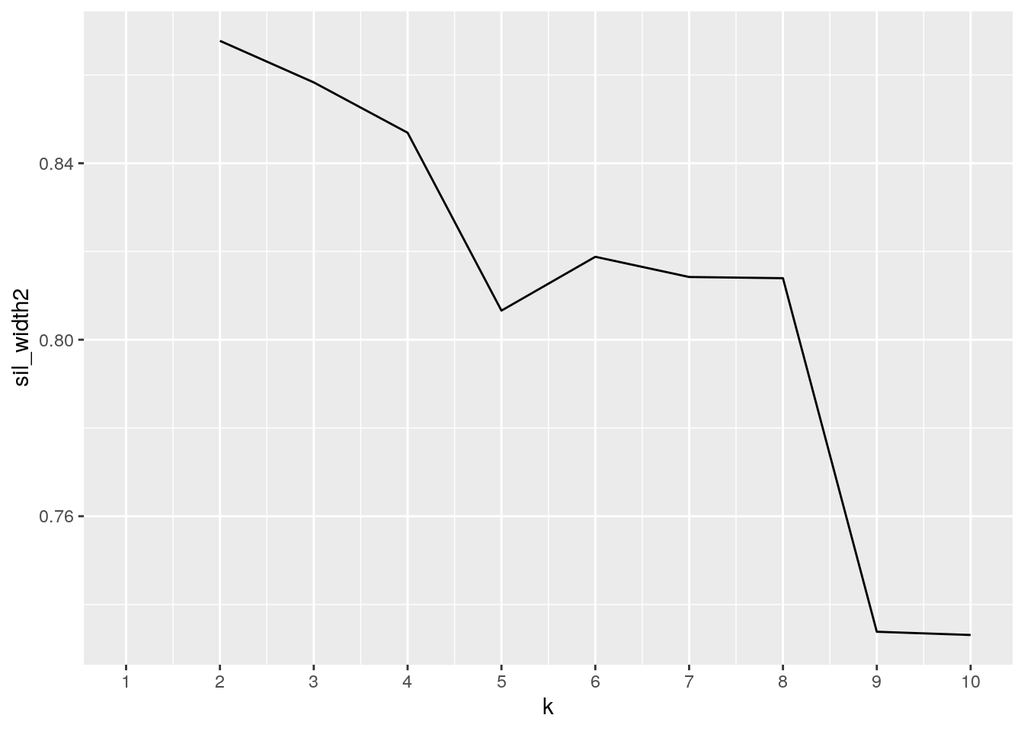

```r
library(cluster)
set.seed(322)
sil_width2 <- vector()
for (i in 2:10) {
    pam_fit <- pam(Presidents, k = i)
    sil_width2[i] <- pam_fit$silinfo$avg.width
}
ggplot() + geom_line(aes(x = 1:10, y = sil_width2)) + scale_x_continuous(name = "k",
    breaks = 1:10)
```

##### Cleaning Up Presidents Dataset

```r
PresidentsCleaned <- Presidents %>% distinct(CandidateName, .keep_all = TRUE)
Presidents1 <- PresidentsCleaned %>% mutate_if(is.character,
    as.factor) %>% column_to_rownames("CandidateName")

# Saving as a vector
Presidentsx <- Presidents1 %>% select_if(is.numeric) %>% as.data.frame
pam <- Presidentsx %>% pam(2)
```

##### Determining how good the solution is

```r
pam$silinfo$avg.width
```

```
## [1] 0.871644
```

```r
pam$silinfo$clus.avg.widths
```

```
## [1] 0.9485222 0.3706957
```

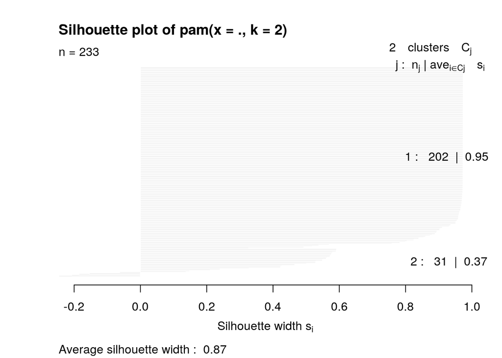

```r
plot(pam, which = 2)
```

##### Summarizing cluster

```r
Presidentsx <- Presidentsx %>% mutate(cluster = as.factor(pam$clustering))
Presidentsx %>% group_by(cluster) %>% summarize_if(is.numeric,
    mean, na.rm = T)
```

```
## # A tibble: 2 x 6
##   cluster ElectionYear PopularVote PopVoteShare ElectoralVotes ElecVoteShare
##   <fct>          <dbl>       <dbl>        <dbl>          <dbl>         <dbl>
## 1 1              1925.    1265553.         11.4           36.4          10.6
## 2 2              1978.   47311822.         56.7          248.           46.2
```

```r
Presidentsx %>% slice(pam$id.med)
```

```
##                     ElectionYear PopularVote PopVoteShare ElectoralVotes
## Peter Camejo                1976       90986         0.11              0
## James E. Carter Jr.         1976    40831881        50.08            297
##                     ElecVoteShare cluster
## Peter Camejo                  0.0       1
## James E. Carter Jr.          55.2       2
```

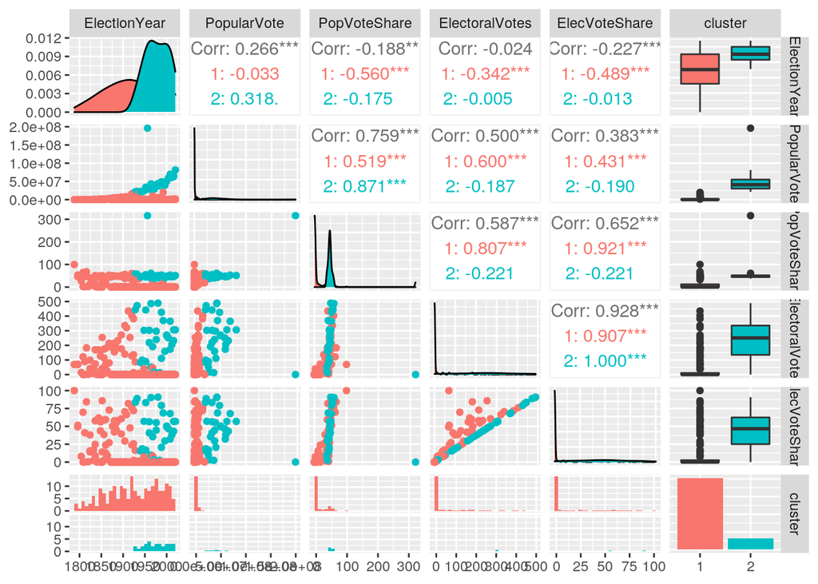

```r
library(GGally)
ggpairs(Presidentsx, aes(color = cluster))
```

According to the ggplot, 2 clusters are suggested. Performing a goodness-of-fit test, we can see that the average silhouette width is 0.871644, suggesting that a strong structure has been found. Prior to performing the PAM function, the numeric variables of the Presidents data set were isolated, using the select_if() function; additionally, the variable “Candidate Name” was mutated to become the row names. According to the slice() function, the candidates that were the 2 medioids were James E. Carter Jr. and Peter Camejo.

The variable that shows the greatest difference between the two clusters is Popular Vote. The variable that shows the least difference between the two clusters is Election Year.

### Dimensionality Reduction with PCA

##### Preparing Data for PCA

```r
poke_nums <- Presidents %>% select_if(is.numeric) %>% scale
rownames(poke_nums) <- Presidents$CandidateName
```

To perform PCA on this data set, I selected for all of the numeric variables [Electoral Vote, Electoral Vote Share, Popular Vote, Popular Vote Share, Election Year]. Furthermore, I named the rows by Candidate Name, so that they could be identified.

##### PCA

```r
poke_PCA <- princomp(poke_nums)
names(poke_PCA)
```

```
## [1] "sdev"     "loadings" "center"   "scale"    "n.obs"    "scores"   "call"
```

##### Determining Which Principal Components to Retain

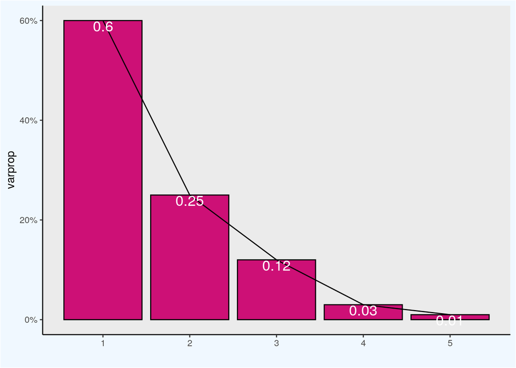

```r
eigval <- poke_PCA$sdev^2
varprop = round(eigval/sum(eigval), 2)
ggplot() + geom_bar(aes(y = varprop, x = 1:5), stat = "identity",
    fill = "deeppink3", col = "black") + xlab("") + geom_path(aes(y = varprop,
    x = 1:5)) + geom_text(aes(x = 1:5, y = varprop, label = round(varprop,
    2)), vjust = 1, col = "white", size = 5) + scale_y_continuous(breaks = seq(0,
    0.6, 0.2), labels = scales::percent) + scale_x_continuous(breaks = 1:10) +
    theme(plot.background = element_rect(fill = "aliceblue"),
        panel.border = element_blank(), panel.grid.major = element_blank(),
        panel.grid.minor = element_blank(), axis.line = element_line(colour = "black"))
```

##### Table of Loadings

```r
summary(poke_PCA, loadings = T)
```

```
## Importance of components:
##                           Comp.1    Comp.2    Comp.3     Comp.4      Comp.5
## Standard deviation     1.7241913 1.1237215 0.7619038 0.37093587 0.175069620
## Proportion of Variance 0.5964369 0.2533442 0.1164646 0.02760522 0.006149151
## Cumulative Proportion  0.5964369 0.8497811 0.9662456 0.99385085 1.000000000
##
## Loadings:
##                Comp.1 Comp.2 Comp.3 Comp.4 Comp.5
## ElectionYear           0.838  0.336  0.422
## PopularVote    -0.417  0.496 -0.471 -0.529  0.281
## PopVoteShare   -0.517        -0.493  0.618 -0.321
## ElectoralVotes -0.525         0.510 -0.337 -0.591
## ElecVoteShare  -0.526 -0.219  0.402  0.215  0.684
```

On axis 1, there are strong, negative loadings for Popular Vote, Popular Vote Share, Electoral Votes and Electoral Share. On axis 2, there are positive loadings for Popular Vote and Election Year, and negative loadings for Electoral Vote Share. This likely explains the fact that, as Election Year increases, the Popular Vote + Popular Vote Share value for candidates increases [increasing yearly population size]

##### Visualizing PC Scores

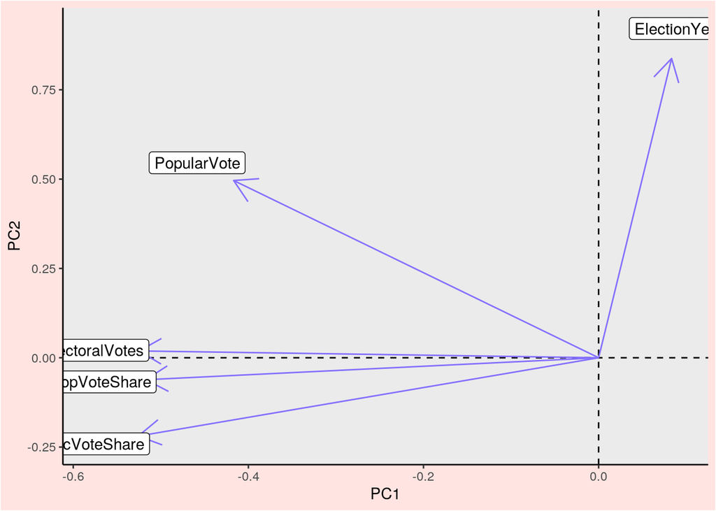

```r
poke_PCA$loadings[1:5, 1:2] %>% as.data.frame %>% rownames_to_column %>%
    ggplot() + geom_hline(aes(yintercept = 0), lty = 2) + geom_vline(aes(xintercept = 0),
    lty = 2) + ylab("PC2") + xlab("PC1") + geom_segment(aes(x = 0,
    y = 0, xend = Comp.1, yend = Comp.2), arrow = arrow(), col = "lightslateblue") +
    geom_label(aes(x = Comp.1 * 1.1, y = Comp.2 * 1.1, label = rowname)) +
    theme(plot.background = element_rect(fill = "mistyrose"),
        panel.border = element_blank(), panel.grid.major = element_blank(),
        panel.grid.minor = element_blank(), axis.line = element_line(colour = "black"))
```

### Linear Classifier

##### Logistic Regression Model

```r
Presidents1 <- Presidents %>% mutate(y = ifelse(Incumbent ==
    "Y", 1, 0))
Presidents1 <- Presidents1 %>% select_if(is.numeric)
fit <- glm(y ~ ., data = Presidents1, family = "binomial")
prob <- predict(fit, type = "response")
class_diag(prob, Presidents1$y, positive = 1)
```

```
##            acc   sens   spec    ppv     f1     ba    auc
## Metrics 0.9091 0.3125 0.9756 0.5882 0.4082 0.6441 0.9077
```

For the model, the accuracy is 0.9091, sensitivity [TPR] is 0.3125, specificity [TNR] is 0.9756, precision [PPV] is 0.5882, and AUC is 0.9077. Due to a low sensitivity, there might be false negatives. However, the AUC value implies that the model is pretty good!

##### Reporting Confusion Matrix

```r
table(predict = as.numeric(prob > 0.5), truth = Presidents1$y) %>%
    addmargins
```

```
##        truth
## predict   0   1 Sum
##     0   280  22 302
##     1     7  10  17
##     Sum 287  32 319
```

##### Cross-validation of Logistic Regression Model

```r
set.seed(1234)
k = 10  #choose number of folds
data <- Presidents1[sample(nrow(Presidents1)), ]  #randomly order rows
folds <- cut(seq(1:nrow(Presidents1)), breaks = k, labels = F)  #create folds
diags <- NULL
for (i in 1:k) {
    ## Create training and test sets
    train <- data[folds != i, ]
    test <- data[folds == i, ]
    truth <- test$y  ## Truth labels for fold i
    ## Train model on training set (all but fold i)
    fit <- glm(y ~ ., data = train, family = "binomial")
    ## Test model on test set (fold i)
    probs <- predict(fit, newdata = test, type = "response")
    ## Get diagnostics for fold i
    diags <- rbind(diags, class_diag(probs, truth, positive = 1))
}
summarize_all(diags, mean)
```

```
##       acc sens    spec     ppv  f1  ba     auc
## 1 0.89938  NaN 0.96865 0.45833 NaN NaN 0.79143
```

### Non-Parametric Classifier

```r
library(caret)
knn_fit <- knn3(y ~ ., data = Presidents1, k = 10)
y_hat_knn <- predict(knn_fit, Presidents1)
class_diag(y_hat_knn[, 1], Presidents1$y, positive = 1)
```

```
##            acc   sens  spec    ppv     f1     ba   auc
## Metrics 0.0972 0.9062 0.007 0.0924 0.1676 0.4566 0.145
```

##### Confusion Matrix

```r
table(truth = factor(Presidents1$y == 1, levels = c("TRUE", "FALSE")),
    prediction = factor(y_hat_knn[, 1] > 0.5, levels = c("TRUE",
        "FALSE"))) %>% addmargins
```

```
##        prediction
## truth   TRUE FALSE Sum
##   TRUE    29     3  32
##   FALSE  285     2 287
##   Sum    314     5 319
```

##### Cross-Validation of NP Classifier

```r
set.seed(1234)
k = 10  #choose number of folds
data <- Presidents1[sample(nrow(Presidents1)), ]  #randomly order rows
folds <- cut(seq(1:nrow(Presidents1)), breaks = k, labels = F)  #create folds
diags <- NULL
for (i in 1:k) {
    ## Create training and test sets
    train <- data[folds != i, ]
    test <- data[folds == i, ]
    truth <- test$y  ## Truth labels for fold i
    ## Train model on training set (all but fold i)
    fit <- knn3(y ~ ., data = train)
    ## Test model on test set (fold i)
    probs <- predict(fit, newdata = test)[, 2]
    ## Get diagnostics for fold i
    diags <- rbind(diags, class_diag(probs, truth, positive = 1))
}
summarize_all(diags, mean)
```

```
##       acc sens   spec ppv  f1  ba     auc
## 1 0.87448  NaN 0.9721 NaN NaN NaN 0.50702
```

After performing a k-fold CV on this same model, an AUC value of 0.50702 was yielded; therefore, the k-fold CV is more accurate. The non-parametric model is not as accurate in its cross-validation performance as the linear model.

### Regression/Numeric Prediction

```r
Presidentslm <- Presidents1 %>% select(-y)
fit <- lm(ElecVoteShare ~ ., data = Presidentslm)  #predict Election Year from all other variables
yhat <- predict(fit)
```

##### Reporting MSE

```r
mean((Presidentslm$ElecVoteShare - yhat)^2)
```

```
## [1] 51.35669
```

##### Cross-validation of Regression Model

```r
set.seed(1234)
k = 5
data <- Presidentslm[sample(nrow(Presidentslm)), ]  #randomly order rows
folds <- cut(seq(1:nrow(Presidentslm)), breaks = k, labels = F)  #create folds

diags <- NULL
for (i in 1:k) {
    train <- data[folds != i, ]
    test <- data[folds == i, ]
    ## Fit linear regression model to training set
    fit <- lm(ElecVoteShare ~ ., data = Presidentslm)
    ## Get predictions/y-hats on test set (fold i)
    yhat <- predict(fit, newdata = test)
    ## Compute prediction error (MSE) for fold i
    diags <- mean((test$ElecVoteShare - yhat)^2)
}
mean(diags)
```

```
## [1] 69.06185
```

### Python

##### R code chunk

```r
library(reticulate)
use_python("/usr/bin/python3")

cool <- "Merry"
```

##### Python code chunk

```python
cool="Christmas!"
print(r.cool,cool)
```

```
## Merry Christmas!
```

```r
library(reticulate)
cat(c(cool, py$cool))
```

```
## Merry Christmas!
```

Using ‘reticulate’, we can share objects between R and python; in my code, I designated the object “cool” in R to give the output “Merry”. I designated the object “cool” in Python to give the output “Christmas!”. To retrieve my object stored in Python, I used the R code “py$cool”. To retrieve my object stored in R, I used the Python code “r.cool”.